# Data preparation

In this notebook, we generate the datasets that will be used for model training and validating. The experiment parameters are obtained from the file `ojdata_forecast_settings.json`; you can modify that file to vary the experimental setup, or just edit the values in this notebook.

The orange juice dataset comes from the bayesm package, and gives pricing and sales figures over time for a variety of orange juice brands in several stores in Florida.

A complicating factor is that the data is in a hybrid of long and wide format: while the sales figures are long (one column of sales data for every store and brand), the prices are wide (one price column for each brand). Therefore we need to reshape the data if we want to use prices for modelling. As part of this, we also compute a new column `maxpricediff`: this represents the log-ratio of the price of this brand compared to the best competing price. A positive `maxpricediff` means this brand is cheaper than all the other brands, and a negative `maxpricediff` means it is more expensive.

```r
settings <- jsonlite::fromJSON("ojdata_forecast_settings.json")

train_periods <- seq(settings$TRAIN_WINDOW, 160 - settings$STEP - 1, settings$STEP)
start_date <- as.Date(settings$START_DATE)

data(orangeJuice, package="bayesm")

oj_data <- orangeJuice$yx %>%
    complete(store, brand, week) %>%
    group_by(store, brand) %>%
    group_modify(~ {
        pricevars <- grep("price", names(.x), value=TRUE)
        thispricevar <- paste0("price", .y$brand)
        best_other_price <- do.call(pmin, .x[setdiff(pricevars, thispricevar)])
        .x$price <- .x[[thispricevar]]
        .x$maxpricediff <- log(best_other_price/.x$price)
        select(.x, week, logmove, deal, feat, price, maxpricediff)
    }) %>%
    ungroup() %>%
    mutate(week=yearweek(start_date + week*7)) %>%  # do this separately because of tsibble/vctrs issues
    as_tsibble(index=week, key=c(store, brand))
```

Here are some glimpses of what the data looks like. The dependent variable is `logmove`, the logarithm of the total sales for a given brand and store, in a particular week. Note that we do *not* fill in the missing values in the data, as (with the exception of `ETS`) the modelling functions in the fable package can handle this innately.

```r
head(oj_data)
```

| store | brand | week | logmove | deal | feat | price | maxpricediff |
| --- | --- | --- | --- | --- | --- | --- | --- |
| 2 | 1 | 1990 W25 | 9.018695 | 1 | 0 | 0.06046875 | -0.8895205 |
| 2 | 1 | 1990 W26 | NA | NA | NA | NA | NA |
| 2 | 1 | 1990 W27 | NA | NA | NA | NA | NA |
| 2 | 1 | 1990 W28 | NA | NA | NA | NA | NA |
| 2 | 1 | 1990 W29 | NA | NA | NA | NA | NA |
| 2 | 1 | 1990 W30 | NA | NA | NA | NA | NA |

The time series plots for a small subset of brands and stores are shown below. It is clear that the statistical behaviour of the data varies by store and brand.

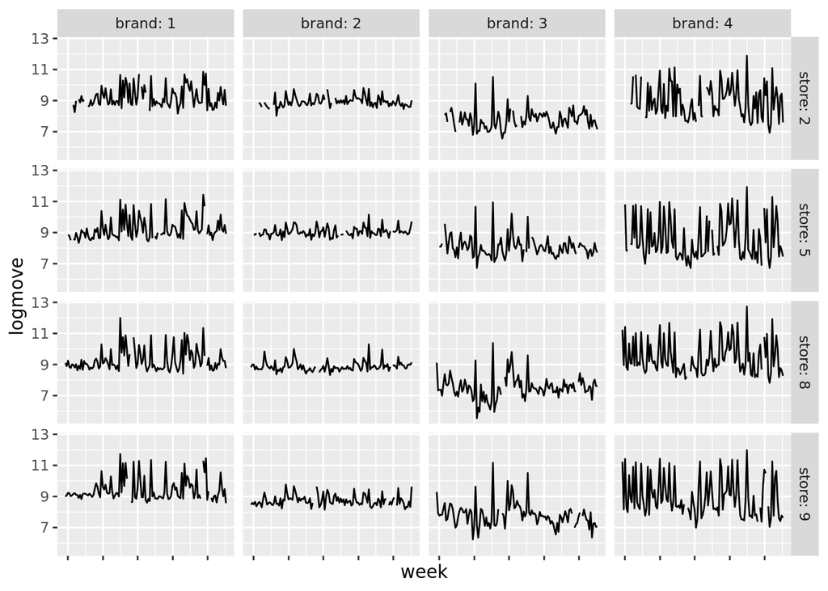

```r
library(ggplot2)

oj_data %>%
    filter(store < 10, brand < 5) %>%
    ggplot(aes(x=week, y=logmove)) +
        geom_line() +
        scale_x_date(labels=NULL) +
        facet_grid(vars(store), vars(brand), labeller="label_both")
```

```r
subset_oj_data <- function(start, end)
{
    start <- yearweek(start_date + start*7)
    end <- yearweek(start_date + end*7)
    filter(oj_data, week >= start, week <= end)
}

oj_train <- lapply(train_periods, function(i) subset_oj_data(40, i))
oj_test <- lapply(train_periods, function(i) subset_oj_data(i + 2, i + settings$STEP + 1))

save(oj_train, oj_test, file="oj_data.Rdata")

head(oj_train[[1]])
```

| store | brand | week | logmove | deal | feat | price | maxpricediff |
| --- | --- | --- | --- | --- | --- | --- | --- |
| 2 | 1 | 1990 W25 | 9.018695 | 1 | 0 | 0.06046875 | -0.8895205 |
| 2 | 1 | 1990 W26 | NA | NA | NA | NA | NA |
| 2 | 1 | 1990 W27 | NA | NA | NA | NA | NA |
| 2 | 1 | 1990 W28 | NA | NA | NA | NA | NA |
| 2 | 1 | 1990 W29 | NA | NA | NA | NA | NA |
| 2 | 1 | 1990 W30 | NA | NA | NA | NA | NA |

```r
head(oj_test[[1]])
```

| store | brand | week | logmove | deal | feat | price | maxpricediff |
| --- | --- | --- | --- | --- | --- | --- | --- |
| 2 | 1 | 1992 W18 | 9.189321 | 0 | 0 | 0.04164469 | -0.6296447 |
| 2 | 1 | 1992 W19 | 9.738613 | 1 | 1 | 0.03734375 | -0.1831587 |
| 2 | 2 | 1992 W18 | 8.738735 | 0 | 0 | 0.05197917 | -0.8513139 |
| 2 | 2 | 1992 W19 | 9.601301 | 1 | 1 | 0.03895833 | -0.2254859 |
| 2 | 3 | 1992 W18 | 7.560080 | 0 | 0 | 0.04765625 | -0.7644847 |
| 2 | 3 | 1992 W19 | 7.249926 | 0 | 0 | 0.04765625 | -0.4270070 |